# Fico Competition

Alicja Gosiewska, Kinga Jamróz, Karolina Marcinkowska

12 czerwca 2018

```r
model_martix_train <- model.matrix(RiskPerformance ~ ., dane)
data_train <- xgb.DMatrix(model_martix_train, label = dane$RiskPerformance)
param <- list(booster = "gbtree", objective = "binary:logistic",
              gamma = 0.1, min_child_weight = 7, eta = 0.025, max_depth = 3,
              subsample = 0.6, colsample_bytree = 0.6)

model_xgboost <- xgb.train(param, data_train, nrounds = 300)
```

# 1 Zbiór danych

Celem zadania jest dopasowanie do danych modelu scoringowego, który najlepiej przewidzi prawdopodobieństwo zaprzestania spłaty kredytu po minimum 90 dniach. Pierwsza faza rozwiązania zadania wraz z wynikami jest dostępna [tu](https://drive.google.com/drive/folders/1WKREMeZgbOXIxOpEJxNtY-7I8XqFUe15).

W tej części nieco inaczej została rozwiązana sprawa brakujących/spejcalnych wartości:

- dla każdej zmienne zostały dodane 3 kolumny-indykatory, kodujące każdy z 3 typów braków danych
- wartości specjalne zostały zastąpione 0 *jeżeli okazało się, że pewne kolumny były wypełnione samymi zerami (tzn. dany typ braku nie wsytępował w tej zmiennej), kolumny te były usuwane.

Otrzymano łącznie 34 zmienne objaśniające i tak przygotowaną ramkę danych wykorzystano w budowie modeli.

# 2 Modele

Została zastosowana 5-krotna kroswalidacja, a miarą jakości modelu było AUC. Dopasowano następujące modele: LDA, QDA, SVM, GLM, las losowy, XGBoost oraz GradientBoosting zarówno dla domyślnych, jak i innych wybranych parametrów.

Poniższa tabelka zawiera uśrednione AUC dla dopasowanych modeli.

|  | AUC |
| --- | --- |
| lda | 0.7348694 |
| qda | 0.6584625 |
| glm | 0.8044687 |
| glmnet (log z karą) | 0.7332738 |
| randomForest regression | 0.7984047 |
| randomForest clasification | 0.7345538 |
| rf cl ntree=1000 | 0.7993665 |
| svm | 0.7960483 |
| gradient boosting | 0.7370055 |
| gradient boosting 3 | 0.8031028 |
| gradient boosting 4 | 0.8010912 |
| xgboost 2 | 0.8052177 |

Najlepszy wynik dla ręcznie dobieranych parametrów uzyskał XGBoost, dlatego też postanowiono automatycznie sprawdzić dla tego modelu więcej parametrów. Przetestowany został nastepujący zakres parametrów we wszystkich możliwych kombinacjach:

- eta: 0.01, 0.015, 0.025, 0.05, 0.1
- max_depth: 3, 5, 7, 9, 12, 17, 25
- nrounds: 100, 300, 500, 700, 900, 1100
- gamma: 0.05, 0.1, 0.5
- min_child_weight = 7
- colsample_bytree = 0.6
- subsumple = 0.6

Najlepszy wynik, który otrzymano przy 5-krotnej kroswalidacji, to średnie AUC = 0.807330 dla modelu o następującym zestawie parametrów: eta=0.025; max_depth=3; subsumple=0.6; colsample_bytree=0.6; nrounds=300; min_child_weight=7; gamma=0.1

Jednoznaczne jednoznaczne wybranie najlepszego modelu okazało się trudne, ponieważ różnica w AUC jest niewielka. Na podstawie tej miary, wybrano najlepsze, trzy różne modele, aby zbadać ich zachowanie za pomacą wyjaśniaczy. Ostatecznie, wybrano:

- xgb_kros z parametrami: eta=0.025; max_depth=3; subsumple=0.6; colsample_bytree=0.6; nrounds=300; min_child_weight=7; gamma=0.1
- glm z parametrami domyślnymi
- gradient boosting 3 z parametrami: distribution = “gaussian”; interaction.depth = 10; shrinkage = 0.03;

Celowo wybrane zostały trzy różne rodziny modeli, gdyż uznano, że podczas próby ich wyjaśniania będzie to o wiele ciekawsze i pouczające porównanie.

# 3 Wyjaśnienia

Aby ustalić, który z wybranych modeli jest najlepszy, dokonano analizy modeli przy pomocy pakietu DALEX.

```r
library(DALEX)
library(auditor)
library(Matrix)
library(xgboost)
library(gbm)
dane<-read.csv("fico_NAver3.csv",h=T, sep=",")
dane$RiskPerformance<-ifelse(dane$RiskPerformance=="Bad",1,0)

#funkcje pomocnicze
pred_glm<-function(model,newdata, type="terms"){
  predict(model,newdata=newdata,type="response")
}
pred_boost<-function(model,newdata){
  predict(model,newdata=newdata,n.trees=model$n.trees)
}


expl_glm<-explain(model_glm,data=dane[,-1],y=dane[,1],predict_function = pred_glm,label = "glm")
expl_xgb <- explain(model_xgboost,
                         data = model_martix_train,
                         y = dane$RiskPerformance,
                         label = "xgboost")
expl_boost<-explain(model_gradient_boosting,data=dane[,-1],y=dane[,1],predict_function = pred_boost)
```

## 3.1 Analiza dopasowania modelu

### 3.1.1 Wykresy reszt

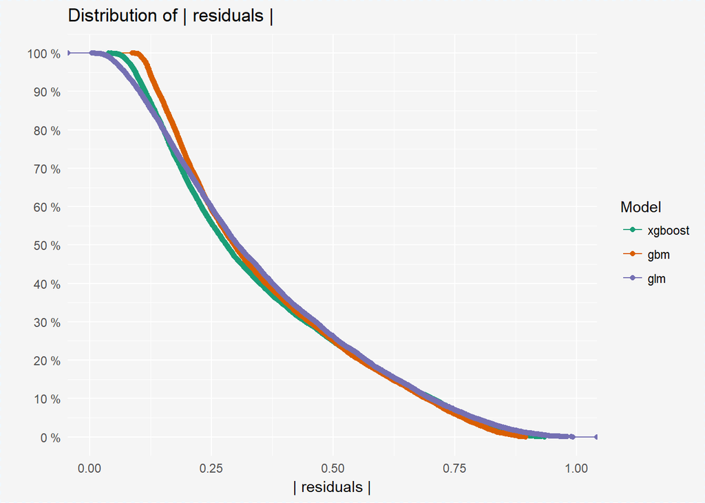

```r
mp_glm<-model_performance(expl_glm)#roznica miedzy prawdziwa klasa (y) a pstwem przynaleznosci do bad
#mp_glm2<-model_performance(expl_glm2)
mp_boost<-model_performance(expl_boost)
mp_xgb<-model_performance(expl_xgb)
plot(mp_glm, mp_boost, mp_xgb)#, mp_glm2)#1-dystrubuanta: np. 40%obserwacji ma reszty niejsze niz 0.25
```

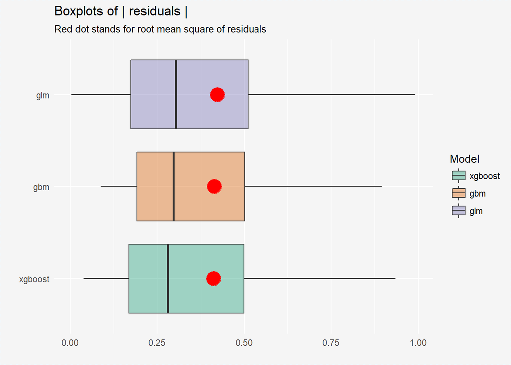

```r
plot(mp_glm, mp_boost, mp_xgb, geom = "boxplot")
```

Wykresy reszt mają podobny rozkład i są skoncentrowane na podobnym poziomie. Na ich podstawie nie jesteśmy w stanie wskazać najlepszego modelu.

## 3.2 Wyjaśnienia globalne

### 3.2.1 Ważność zmiennych

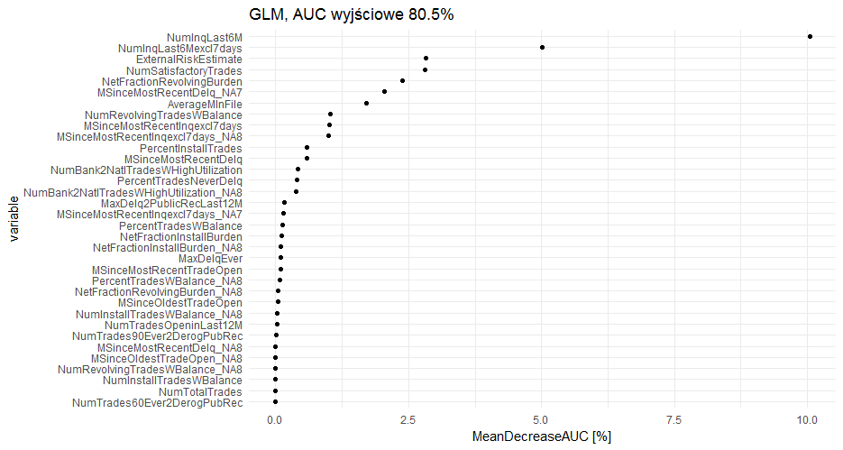

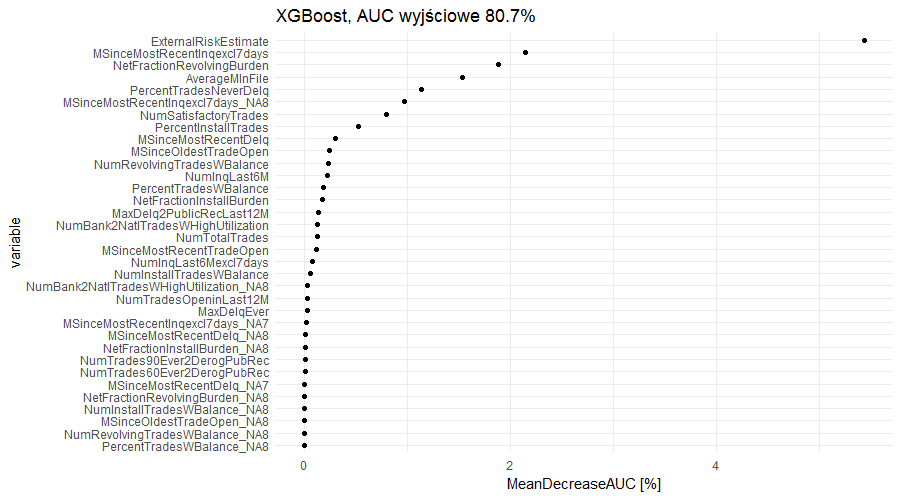

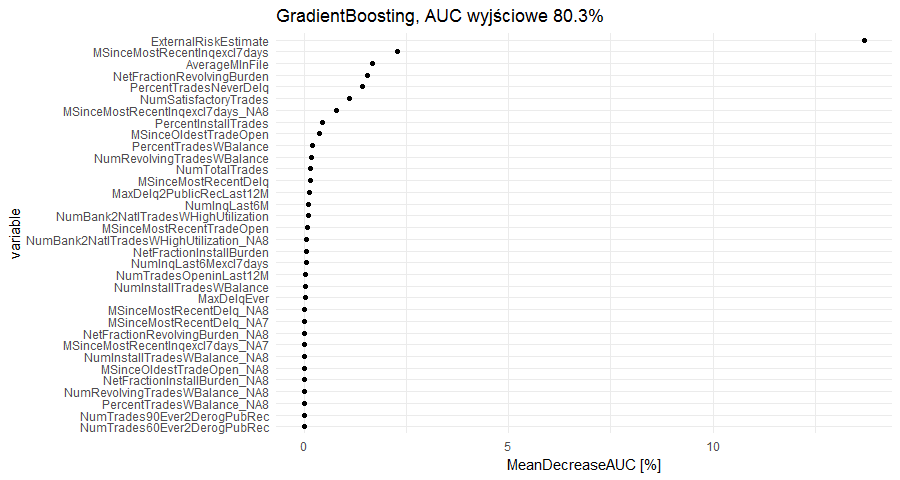

### 3.2.2 PDP

Wymienione powyżej zmienne uznane zostały za wystarczająco interesujące aby przedstawić je na wykresach typu partial dependence plot (pdp). Wykresy te pokazują, jak odpowiedź każdego z trzech modeli zależy od zmiennych `ExternalRiskRate` oraz odpowiednio `NumInqLast6M` przy ustalonych wartościach dla pozostałych zmiennych.

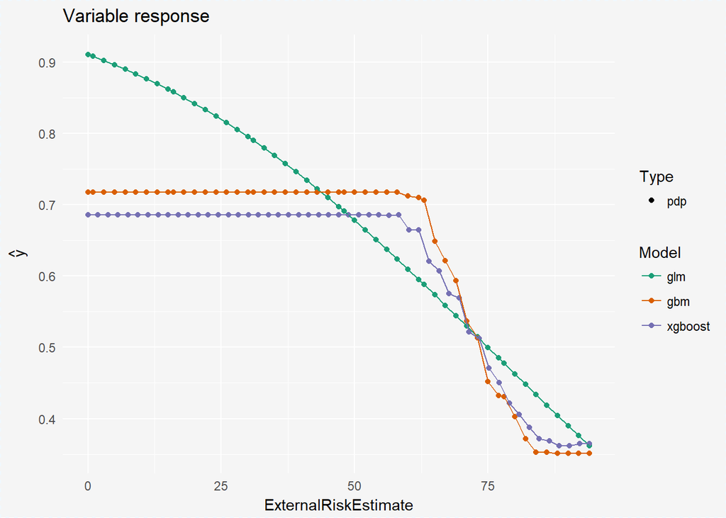

```r
vr_glm<-variable_response(expl_glm,type="pdp",variable="ExternalRiskEstimate")
#vr_glm2<-variable_response(expl_glm2,type="pdp",variable="ExternalRiskEstimate")
vr_boost<-variable_response(expl_boost,n.trees=model_gradient_boosting$n.trees, type="pdp",variable="ExternalRiskEstimate")
vr_xgb <- variable_response(expl_xgb,type="pdp",variable="ExternalRiskEstimate")
plot(vr_glm, vr_boost, vr_xgb)
```

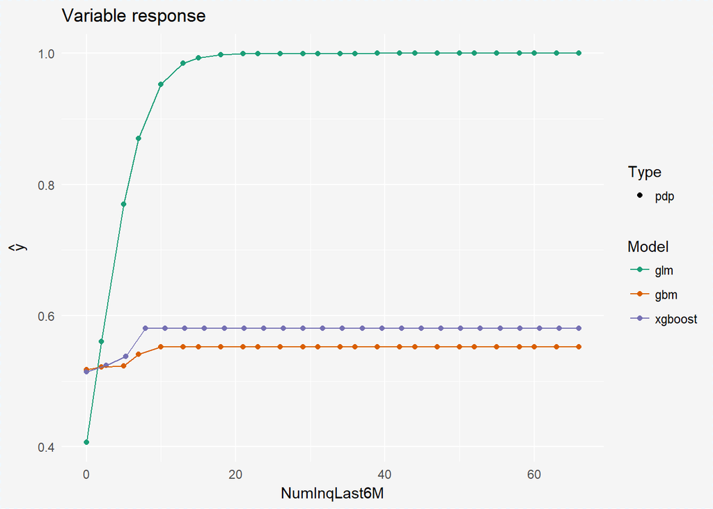

```r
vr_glm<-variable_response(expl_glm,type="pdp",variable="NumInqLast6M")
vr_boost<-variable_response(expl_boost,type="pdp",variable="NumInqLast6M",
                            n.trees=model_gradient_boosting$n.trees)
vr_xgb<-variable_response(expl_xgb,type="pdp",variable="NumInqLast6M")
plot(vr_glm,vr_boost,vr_xgb)
```

Dla zmiennej `NumInqLast6M` wykres pdp pokazuje, że począwszy od wartości około 20, model liniowy przyporządkowuje obserwacjom klasę `Bad`. To potwierdza, że zmienna jest bardzo istotna w tym modelu, gdyż w bardzo wielu przypadkach determinuje niespłacenie kredytu. Pozostałe modele zwracają prawdopodobieństwo oscylujące w okolicy 0.5, więc nie wpływa to mocno na wybór konkretnej klasy.

### 3.2.3 ALE

Poniższy wykres, podobnie jak pdp, przedstawia częściową zależność odpowiedzi modelu od wartości konktretnej zmiennej, ale uwzględniając tylko obserwacje w pewnym otoczeniu dla każdej wartości.

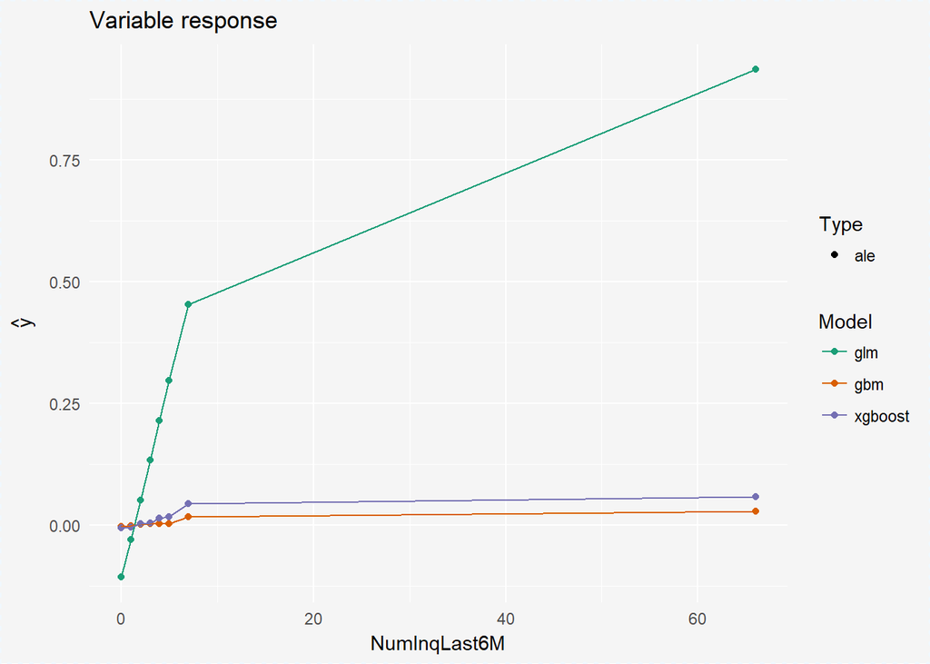

```r
vr_glm<-variable_response(expl_glm,type="ale",variable="NumInqLast6M")
vr_boost<-variable_response(expl_boost,type="ale",variable="NumInqLast6M",
                            n.trees=model_gradient_boosting$n.trees)
vr_xgb<-variable_response(expl_xgb,type="ale",variable="NumInqLast6M")
plot(vr_glm, vr_boost, vr_xgb)
```

Przedstawiony wykres dla zmiennej`NumInqLast6M` pokazuje, że modele drzewiaste, które na wykresie pdp zawsze zwracały prawdopodobieństwo w okolicach 0.5, tutaj dają odpowiedź blisko zera, czyli klasę `Good (spłaci kredyt). Dla modelu liniowego zauważamy pewną rosnącą tendencję, jednak odrobinę różną niż na poprzednim wykresie.

## 3.3 Wyjaśnienia lokalne

### 3.3.1 Cateris Paribus

```r
#devtools::install_github("pbiecek/ceterisParibus")

library(ceterisParibus)
```

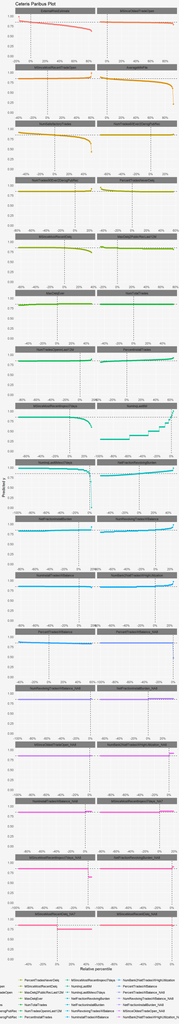

```r
cp_glm <- ceteris_paribus(expl_glm, observation = dane[10,])
#cp_xgb <- ceteris_paribus(expl_xgb, observation = model_martix_train[10, , drop = FALSE])
cp_boost <- ceteris_paribus(expl_boost, observation = dane[10,])
plot(cp_glm) + facet_wrap(~vname, scales = "free_x", ncol = 2)
```

### 3.3.2 break

```r
#break_glm <- prediction_breakdown(expl_glm, observation =  dane[10,])
```